# Lab 01 - Programación en R

## Ejercicio 1

Escribe una función que devuelva $k$ números, donde cada número es la suma de $n$ números escogidos al azar entre 1 y 100 (con reemplazamiento), divido entre n.

Pinta un histograma con los resultados de $k=10000$ para $n=1$, $n=2$, $n=10$ y $n=100$. Pista: puedes usar la función `hist()`.

¿Qué observas?

### Solución

Definimos la función

```r
gen <- function(k=10, n=5){

  result <- c()
  for(i in 1:k){
    nums <- sample(1:100, size=n, replace=TRUE)
    result <- c( result, sum(nums) )
  }

  return(result)
}
```

Pintamos los histogramas

- $n=1$

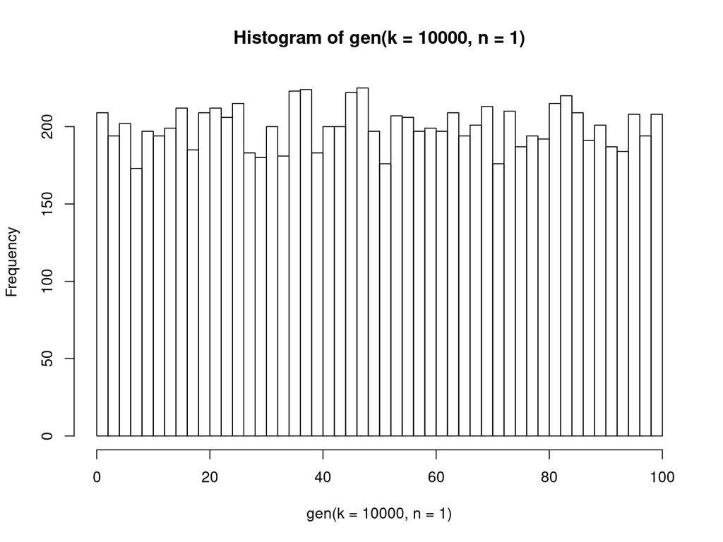

```r
hist( gen(k=10000, n=1), breaks = 50 )
```

- $n=2$

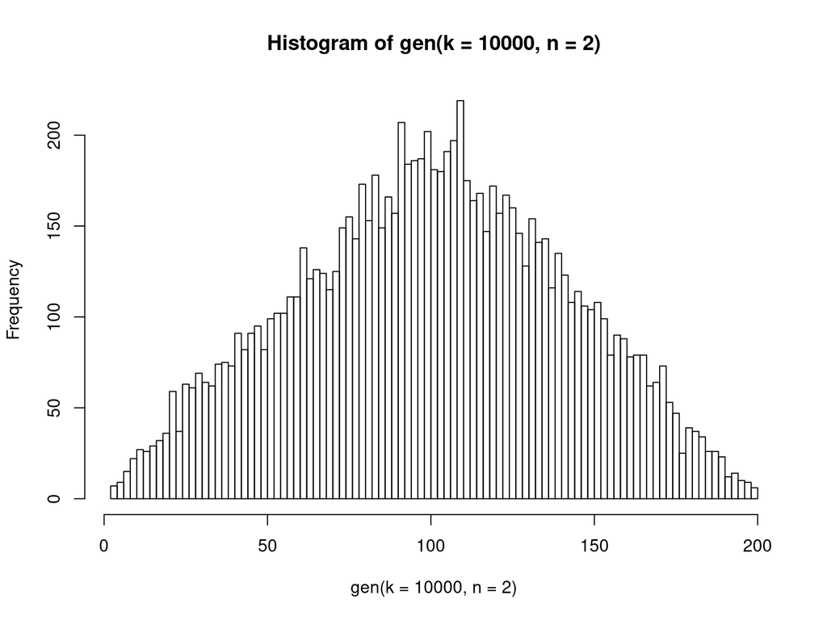

```r
hist( gen(k=10000, n=2), breaks = 101 )
```

- $n=10$

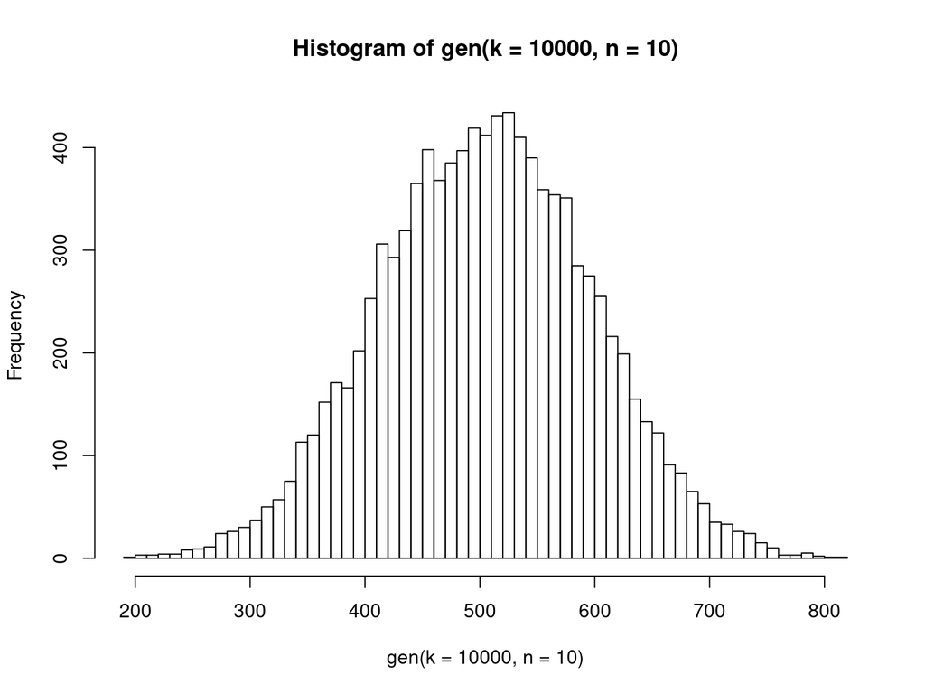

```r
hist( gen(k=10000, n=10), breaks = 50 )
```

- $n=100$

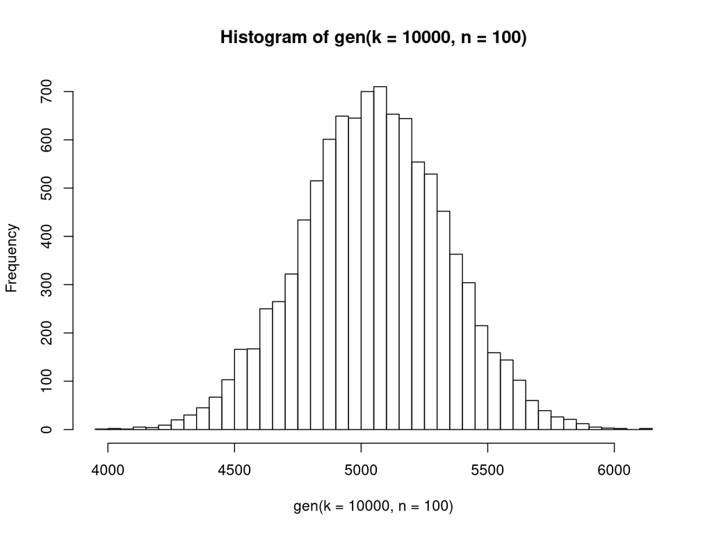

```r
hist( gen(k=10000, n=100), breaks = 50 )
```

La distribución se aproxima a una **distribución normal**.

## Ejercicio 2

Utiliza la ayuda de la función `replicate()` para conocer su funcionamiento. Resuelve el Ejercicio 1 sin usar un bucle (si es que lo habías usado).

### Solución

Definimos la función, esta vez sin bucles

```r
aux <- function(n=5){

  nums <- sample(1:100, size=n, replace=TRUE)
  return( sum(nums) )
}

gen2 <- function(k=10, n=5){
  return( replicate(k, aux(n)) )
}
```

- $n=1$

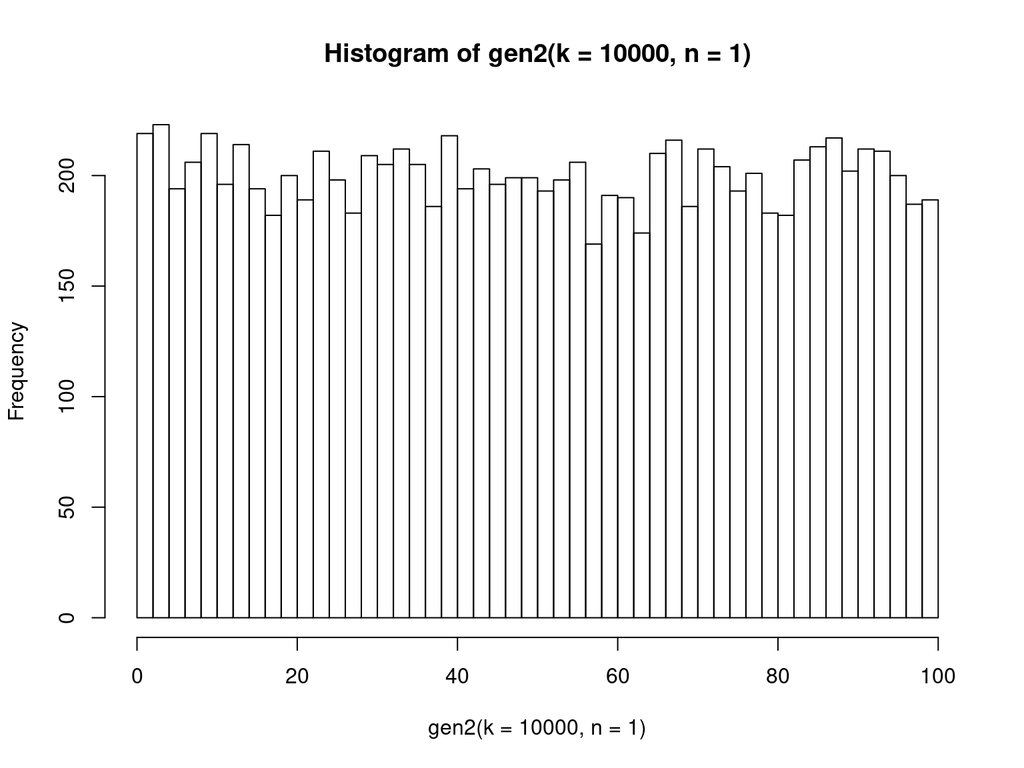

```r
hist( gen2(k=10000, n=1), breaks = 50 )
```

- $n=2$

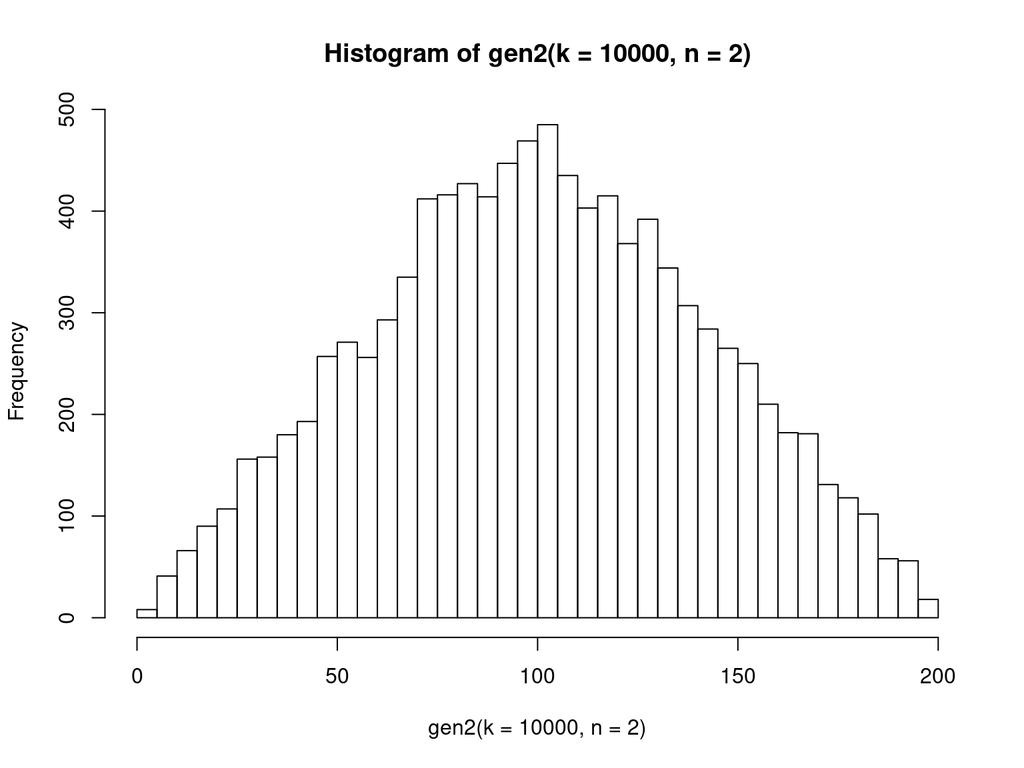

```r
hist( gen2(k=10000, n=2), breaks = 50 )
```

- $n=10$

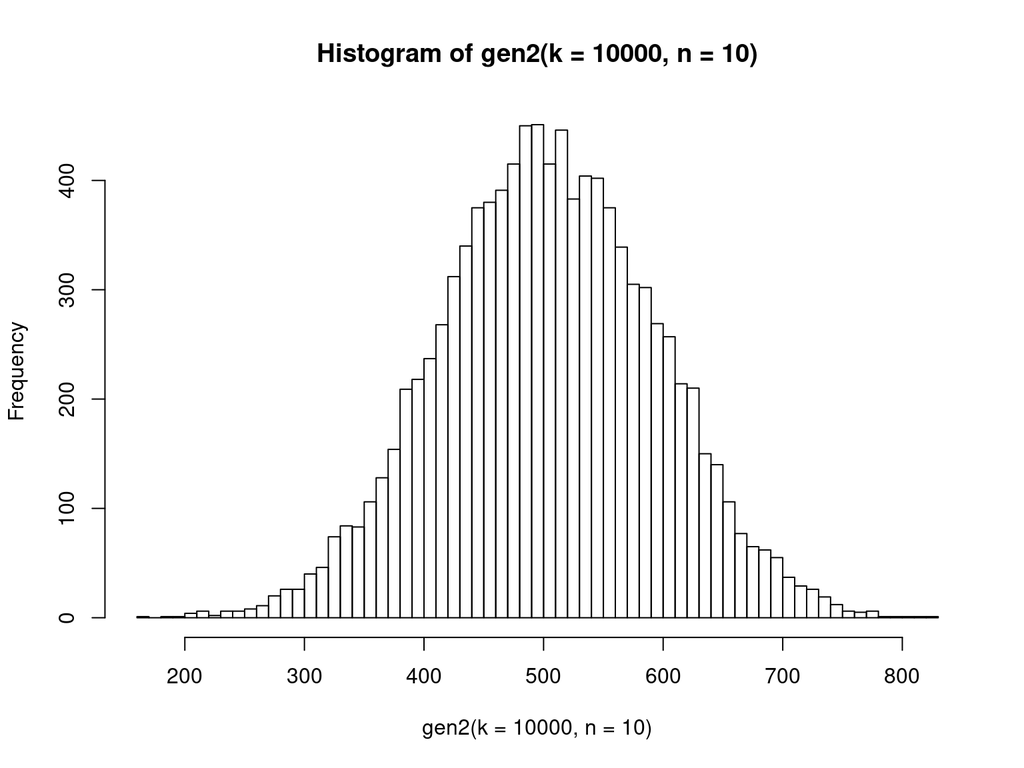

```r
hist( gen2(k=10000, n=10), breaks = 50 )
```

- $n=100$

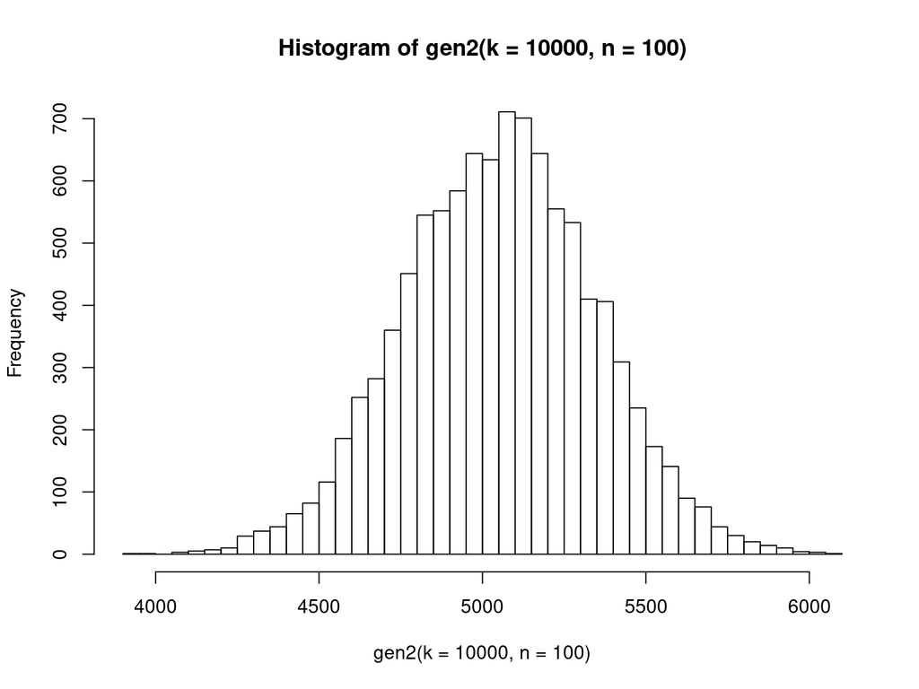

```r
hist( gen2(k=10000, n=100), breaks = 50 )
```

## Ejercicio 3

La base de datos `mtcars` de R contiene información extraída de la *1974 Motor Trend US magazine* acerca de 10 aspectos de diseño de rendimiento de 32 vehículos. Usando esta base de datos, calcula

**Pregunta 1.** La diferencia entre el consumo medio de los vehículos de transmisión automática y los de transmisión manual.

**Pregunta 2.** La misma diferencia pero únicamente para vehículos de más de 3000 lbs.

Pista: la ayuda ?mtcars te puede ser útil

### Solución

**Pregunta 1.**

```r
mean( mtcars[mtcars$am == 0, "mpg"] ) - mean( mtcars[mtcars$am == 1, "mpg"] )
```

```
## [1] -7.244939
```

**Pregunta 2.**

```r
mean( mtcars[mtcars$am == 0 & mtcars$wt > 3, "mpg"] ) - mean( mtcars[mtcars$am == 1 & mtcars$wt > 3, "mpg"] )
```

```
## [1] 1.505556
```

## Ejercicio 4

Utilizando un bucle `for` y un `if`, suma los números pares entre 1 y 100 (ambos incluidos).

### Solución

```r
sum <- 0
for(i in 1:100){
  if(i%%2 == 0){
    sum <- sum + i
  }
}
sum
```

```
## [1] 2550
```

Sin bucle podríamos hacer:

```r
sum(seq(2,101,by=2))
```

```
## [1] 2550
```

## Ejercicio 5

Calcula la ganancia esperada de la estrategia de ruleta que consiste en apostar 10 euros siempre al rojo.

Para ello:

- Crea una función llamada `spin()` que devuelva un número muestreado al azar entre 0 y 36 (ambos incluidos).
- Crea otra función llamada `compute_gain()` que tenga un argumento `q` referido a la cantidad de dinero de la apuesta, con valor por defecto de 10. Esta función, ha de generar un tirada de la ruleta y, en función del resultado, calcular la ganancia y devolverla. Recuerda que
  - Los números (1,3,7,9,19,21,23,25,27,12,14,16,18,30,32,34,36) tienen color rojo.
  - Los números (2,4,6,8,20,22,24,26,28,11,13,15,17,29,31,33,35) tienen color negro.
  - El cero no tiene color.
- Por último, crea un bucle que simule 10.000 partidas de la ruleta, almacena la ganancia generada en cada una y calcula la media. ¿Qué observas?

## Solución

Creamos primero al función `spin()`

```r
spin <- function(){
  sample(0:36, size = 1)
}
```

Y la función `compute_gain()`

```r
red   <- c(1,3,7,9,19,21,23,25,27,12,14,16,18,30,32,34,36)
black <- c(2,4,6,8,20,22,24,26,28,11,13,15,17,29,31,33,35)

compute_gain <- function(q=10){
  result <- spin()
  if(result %in% red){
    return(q)
  }
  else{
    return(-q)
  }
}
```

Por último hacemos el bucle

```r
K=10000
ganancias <- c()
for(i in 1:K){
  ganancias <- c(ganancias, compute_gain(1))
}
```

Podemos representar esto gráficamente

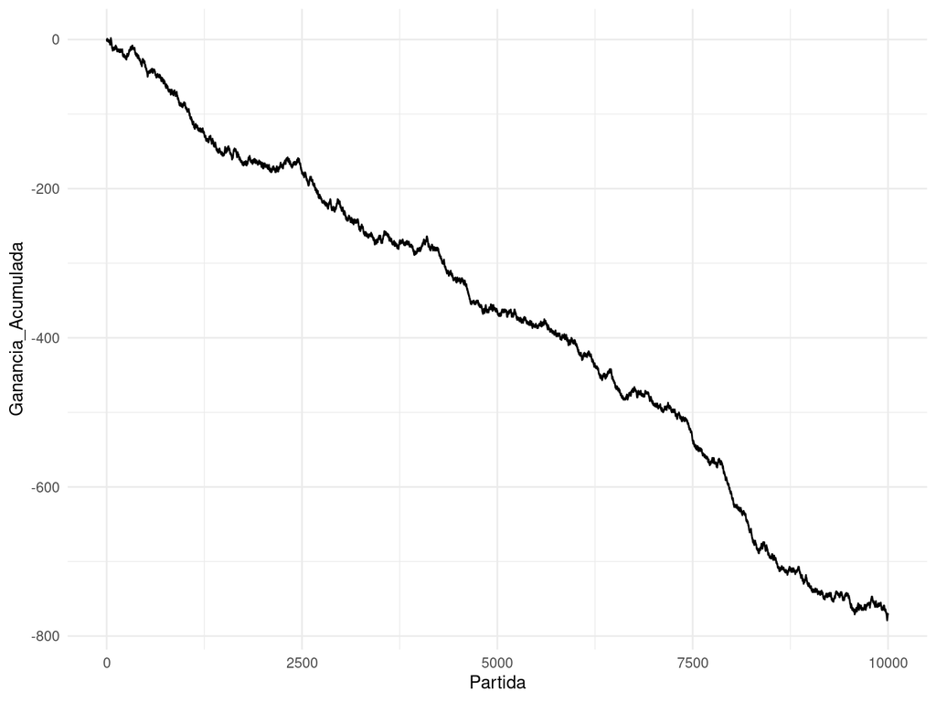

```r
library(ggplot2)

results = data.frame(Partida = 1:K, Ganancia_Acumulada = cumsum(ganancias) )

p <- ggplot(results, aes(x=Partida, y=Ganancia_Acumulada)) +
  geom_line() + theme_minimal()

p
```